# final_E_learning_project_Ankushev

## Финальный проект

Выполнил: Владислав Анкушев

Вариант №2

Исправленная версия!

### Загрузка библиотек и доп. функций

```python
# Библиотеки
import pandas as pd
import numpy as np
import seaborn as sns
import matplotlib.pyplot as plt
from scipy import stats
from math import sqrt

# Функции:
# 1 – Вывод двух результатов на одной странице
# 2 – Бустрапирование
# 3 – Размер эффекта для т-теста
# (они находятся в файле – functions.py)
from functions_final import display_side_by_side, get_bootstrap, cohen_d


# Скрываем ошибки
import warnings
warnings.filterwarnings("ignore")
```

### Нагивация по проекту:

- Задание №1. A/B–тестирование
- Задание №2. SQL
- Задание №3. Функция метрик

### Задание №1. A/B–тестирование

**Условие:**

- Одной из основных задач аналитика в нашей команде является корректное проведение экспериментов. Для этого мы применяем метод A/B–тестирования.
- В ходе тестирования одной гипотезы целевой группе была предложена новая механика оплаты услуг на сайте, у контрольной группы оставалась базовая механика.
- В качестве задания Вам необходимо проанализировать итоги эксперимента и сделать вывод, стоит ли запускать новую механику оплаты на всех пользователей.

**Описание дата-сетов**

- **groups.csv** – файл с информацией о принадлежности пользователя к контрольной или экспериментальной группе  
  (А – контроль, B – целевая группа)
- **group_add.csv** – дополнительный файл с пользователями, который вам прислали спустя 2 дня после передачи данных
- **active_studs.csv** – файл с информацией о пользователях, которые зашли на платформу в дни проведения эксперимента
- **checks.csv** – файл с информацией об оплатах пользователей в дни проведения эксперимента.

**Вопросы**

1. На какие метрики Вы смотрите в ходе анализа и почему?
1. Имеются ли различия в показателях и с чем они могут быть связаны?
1. Являются ли эти различия статистически значимыми?
1. Стоит ли запускать новую механику на всех пользователей?

### Логика решения

**Условия:**

- Тестим новую механику оплаты услуг
- Продукт – сайт

**Мы имеем в данных:**

- айди пользователей
- принадлежность к группе
- доп. пользователей
- айди пользователей, кто зашел на продукт
- айди пользователей, кто купил продукт
- доход с одного пользователя

**Возникают следующие метрики на уме:**

- Конверсия в покупку (без учета времени)
- Средний чек (с платящего пользователя)
- ARPU (без учета времени)
- ARPPU (без учета времени)

### Мои условия

- Мы не обговаривали с заказчиком метрики, поэтому не знаем, что считать выбросом
  - Следовательно, я считаю, что дата-сет не имеет выбросов
- Договоримся, что мы работаем с конвенциональным значением 0.05 для p-value и 0.8 для мощности
- Размеры эффекта в метриках также не были обговорены. Поэтому, решение на основе их значений я приму самостоятельно!

### Загрузим дата-сеты!

```python
groups = pd.read_csv('groups.csv', sep=';')
group_add = pd.read_csv('group_add.csv')
active_studs = pd.read_csv('active_studs.csv')
checks = pd.read_csv('checks.csv', sep=';')
```

### Базовая проверка

Совпадают ли уникальные значения с кол-во строк в дата-сете?

```python
# Основной дата-сет
print('groups unique num –', groups.id.nunique())
print('groups nrow –', groups.id.count())
```

```
groups unique num – 74484
groups nrow – 74484
```

```python
# Доп. дата-сет
print('group_add unique num –', group_add.id.nunique())
print('group_add nrow –', group_add.id.count())
```

```
group_add unique num – 92
group_add nrow – 92
```

```python
# Дата-сет активных пользователей
print('active_studs unique num –', active_studs.student_id.nunique())
print('active_studs nrow –', active_studs.student_id.count())
```

```
active_studs unique num – 8341
active_studs nrow – 8341
```

```python
# Дата-сет оплаты
print('checks unique num –', checks.student_id.nunique())
print('checks nrow –', checks.student_id.count())
```

```
checks unique num – 541
checks nrow – 541
```

**Ответ**: Все ок, везде совпадают!

#### Проверим тип данных и кол-во NA в каждом дата-сете

```python
# Тип данных
display_side_by_side(groups.dtypes.reset_index(),
                     group_add.dtypes.reset_index(),
                     active_studs.dtypes.reset_index(),
                     checks.dtypes.reset_index(),
                     titles=['groups', 'group_add',
                             'active_studs', 'checks'])
```

groups

|  | index | 0 |
| --- | --- | --- |
| 0 | id | int64 |
| 1 | grp | object |

group_add

|  | index | 0 |
| --- | --- | --- |
| 0 | id | int64 |
| 1 | grp | object |

active_studs

|  | index | 0 |
| --- | --- | --- |
| 0 | student_id | int64 |

checks

|  | index | 0 |
| --- | --- | --- |
| 0 | student_id | int64 |
| 1 | rev | float64 |

```python
# Кол-во NA
display_side_by_side(groups.isna().value_counts().reset_index(),
                     group_add.isna().value_counts().reset_index(),
                     active_studs.isna().value_counts().reset_index(),
                     checks.isna().value_counts().reset_index(),
                     titles=['groups', 'group_add',
                             'active_studs', 'checks'])
```

groups

|  | id | grp | 0 |
| --- | --- | --- | --- |
| 0 | False | False | 74484 |

group_add

|  | id | grp | 0 |
| --- | --- | --- | --- |
| 0 | False | False | 92 |

active_studs

|  | student_id | 0 |
| --- | --- | --- |
| 0 | False | 8341 |

checks

|  | student_id | rev | 0 |
| --- | --- | --- | --- |
| 0 | False | False | 541 |

**Ответ**: тип данных ок, NA нет ни в одном дата-сете!

### Соединим 4 дата-сета

##### Логика:

1. Склеить основной дата-сет и group_add, с помощью pd.concat (чтобы данные склеились сверху-вниз)
2. Добавить булевую колонку: проверить условие – если айдишники склеенного дата-сета совпадают с айдишниками из active_studs
3. Добавить левый-мердж между склеенным дата-сетом и checks (поскольку не все пользователи совершили покупку)
4. Заполнить колонку с чеками (на всякий случай)

```python
# Склеивание основного дата-сета и дополнительного
connected_data = pd.concat([groups, group_add],
                           ignore_index=True, sort=False)

# Добавление булевой колонки
connected_data['activity'] = np.isin(connected_data['id'],
                                     active_studs['student_id']).tolist()

# Переименование колонки, чтобы merge сработало
checks = checks.rename(columns={
    'student_id': 'id'
})

# Склеивание с помощью left-merge
full_data = connected_data.merge(checks, on='id', how='left')

# Заполним NA в колонке с чеками (нулями)
full_data['rev'] = full_data.rev.fillna(0)
```

#### Проверим, правильно ли все склеелось?

1. Сохраняется ли размер у groups, group_add и склееного дата-сета?

```python
print('groups nrow –', groups.shape[0])
print('groups_add nrow –', group_add.shape[0])
print('sum nrow –', groups.shape[0], '+',
      group_add.shape[0], '=', groups.shape[0] + group_add.shape[0])
print('connected_data nrow –', full_data.shape[0])
```

```
groups nrow – 74484
groups_add nrow – 92
sum nrow – 74484 + 92 = 74576
connected_data nrow – 74576
```

**Ответ:** да, все ок

1. При добавлении булевой колонки – все ли строки вошли в основной дата-сет?

```python
print('Кол-во активных пользователей в основном дата-сете (True) \n',
      full_data.activity.value_counts(), '\n')

print('Кол-во активных пользователей в active_studs:',
      active_studs['student_id'].count())
```

```
Кол-во активных пользователей в основном дата-сете (True)
 False    66235
True      8341
Name: activity, dtype: int64

Кол-во активных пользователей в active_studs: 8341
```

**Ответ:** да, все вошли, все ок

1. Все ли пользователи, кто купил продукт, вошли в основной дата-сет?

```python
print('Кол-во платящих пользователей в основном дата-сете:',
      full_data.query('rev > 0').id.count(), '\n')

print('Кол-во платящих пользователей в checks:', checks.rev.count())
```

```
Кол-во платящих пользователей в основном дата-сете: 541

Кол-во платящих пользователей в checks: 541
```

**Ответ:** да, все вошли, все ок

#### Проверка ошибки: кол-во пользователей, кто не вошел в приложение, но купил продукт

```python
full_data.query('activity == False & rev > 0').id.count()
```

```
149
```

#### Интерпретация:

1. Специфика покупки товаров в условиях задания не была описана подробно
2. Поэтому, скорее всего это ошибка
3. Возможны две ситуации:
   - система неверно проставила этих пользователей как неактивных
   - транзакция долго доходила до приложения: до эксперимента пользователи купили товар, а их транзакция дошла только во время проведения эксперимента

#### Вывод:

Условия задания туманны, поэтому я выберу исход первой ситуации.  
Следовательно, нужно **изменить статус этих пользователей**

#### Меняем статус пользователей и добавляем перепроверку

```python
# Изменение статуса пользователей
full_data['activity'] = np.where(full_data['rev'] > 0,
                                 True, full_data.activity)

# Перепроверка:
print('Кол-во платящих и пассивных пользователей в основном дата-сете:',
      full_data.query('activity == False & rev > 0').id.count())

print('Кол-во платящих и активных пользователей в основном дата-сете:',
      full_data.query('activity == True & rev > 0').id.count())

print('Кол-во платящих пользователей в checks: ', checks.id.count())

print('Кол-во активных пользователей в active_studs:',
      active_studs['student_id'].count())

print('------------------------------------------------------------------ \n')

print(active_studs['student_id'].count(), '+',
      149, '=',
      active_studs['student_id'].count() + 149)

print('Кол-во активных пользователей в основном дата-сете (после изменений):',
      full_data.query('activity == True').id.count())
```

```
Кол-во платящих и пассивных пользователей в основном дата-сете: 0
Кол-во платящих и активных пользователей в основном дата-сете: 541
Кол-во платящих пользователей в checks:  541
Кол-во активных пользователей в active_studs: 8341
------------------------------------------------------------------

8341 + 149 = 8490
Кол-во активных пользователей в основном дата-сете (после изменений): 8490
```

**Комментарий**: все ок, пользователи поменяли свой статус, продолжаем!

### Подсчет основных метрик

#### CR - конверсия в покупку

```python
cr_data = full_data.query('activity == True') \
    .groupby('grp', as_index=False) \
    .agg({'activity':'count'})

cr_data['payment'] = full_data.query('rev > 0') \
                    .groupby('grp').agg({'activity':'count'}) \
                    .activity.to_list()

cr_data['cr_coeff'] = round((cr_data.payment / cr_data.activity) * 100, 2)

cr_data
```

|  | grp | activity | payment | cr_coeff |
| --- | --- | --- | --- | --- |
| 0 | A | 1567 | 107 | 6.83 |
| 1 | B | 6923 | 434 | 6.27 |

#### Все подсчитано

Переходим к подсчету следующей метрики

#### Средний чек (с платящего пользователя)

```python
avg_check = full_data.query('rev > 0').groupby('grp', as_index=False) \
            .agg({'rev':'mean'}).round(2).rename(columns={'rev':'avg_check'})
avg_check
```

|  | grp | avg_check |
| --- | --- | --- |
| 0 | A | 860.71 |
| 1 | B | 1108.82 |

**Все подсчитано** НО!  
У среднего чека есть минусы: он чувствителен к выбросам

- Однако, мы не обсуждали метрики с заказчиками и не знаем, что ок, а что является выбросом.
- Поэтому, продолжим работать со средним чеком и не будем рассматривать выбросы.
- В будущем, если понадобиться, то проверим медианный чек и обсудим выбросы.

#### Подсчет метрик ARPU и ARPPU

```python
# ARPU
arpu_data = full_data.query('activity == True') \
    .groupby('grp', as_index=False).agg({'id':'count', 'rev':'sum'}) \
    .rename(columns={'id':'num_users'}).round()

arpu_data['arpu'] = round(arpu_data['rev'] / arpu_data['num_users'],1)

# ARPPU
arppu_data = full_data.query('activity == True & rev > 0') \
    .groupby('grp', as_index=False).agg({'id':'count', 'rev':'sum'}) \
    .rename(columns={'id':'num_users'}).round()

arppu_data['arppu'] = round(arppu_data['rev'] / arppu_data['num_users'],1)

display_side_by_side(arpu_data, arppu_data,
                     titles=['ARPU', 'ARPPU'])
```

ARPU

|  | grp | num_users | rev | arpu |
| --- | --- | --- | --- | --- |
| 0 | A | 1567 | 92096.0 | 58.8 |
| 1 | B | 6923 | 481230.0 | 69.5 |

ARPPU

|  | grp | num_users | rev | arppu |
| --- | --- | --- | --- | --- |
| 0 | A | 107 | 92096.0 | 860.7 |
| 1 | B | 434 | 481230.0 | 1108.8 |

**Все подсчитано!**

### Проверим нормальность распределения всех метрик!

**Цель:** эксплораторно выяснить распределения у большинства метрик перед проведением стат. тестов

**Процедура:** будем везде использовать Шапиро-Уилка, поскольку в этом критерии нам не нужно задавать параметры для распределения  
(ссылка: https://stats.stackexchange.com/questions/362/what-is-the-difference-between-the-shapiro-wilk-test-of-normality-and-the-kolmog)

**Примечание**: тестим все метрики, кроме конверсии, поскольку тип этой метрики – категориальный

#### Оценка общего распределения чека для обеих групп

```python
# Группа А
print('Group A: ', 'stats:',
      stats.shapiro(full_data.query('rev > 0 & grp == "A"').rev)[0],
      '  pvalue:',
      stats.shapiro(full_data.query('rev > 0 & grp == "A"').rev)[1])

# Группа B
print('Group B: ', 'stats:',
      stats.shapiro(full_data.query('rev > 0 & grp == "B"').rev)[0],
      '  pvalue:',
      stats.shapiro(full_data.query('rev > 0 & grp == "B"').rev)[1])
```

```
Group A:  stats: 0.7196124196052551   pvalue: 5.321687643507211e-13
Group B:  stats: 0.8672363758087158   pvalue: 8.947892893418603e-19
```

#### Интерпретация:

- Обе группы ненормально распределены:
  - p-value's < 0.05
  - Отклоняем H0 = распределения метрик имеют нормальную форму

**Вывод**: данные по чеку в обеих группах ненормально распределены

#### Оценка распределения чеков выборок ARPU для обеих групп

```python
# Группа А
print('Group A: ', 'stats:',
      stats.shapiro(full_data.query('activity == True & grp == "A"').rev)[0],
      '  pvalue:',
      stats.shapiro(full_data.query('activity == True & grp == "A"').rev)[1])

# Группа B
print('Group B: ', 'stats:',
      stats.shapiro(full_data.query('activity == True & grp == "B"').rev)[0],
      '  pvalue:',
      stats.shapiro(full_data.query('activity == True & grp == "B"').rev)[1])
```

```
Group A:  stats: 0.1949470043182373   pvalue: 0.0
Group B:  stats: 0.22011637687683105   pvalue: 0.0
```

#### Интерпретация:

- Обе группы ненормально распределены:
  - p-value's < 0.05
  - Отклоняем H0 = распределения метрик имеют нормальную форму

**Вывод**: данные по чеку в выборках ARPU для обеих групп ненормально распределены

#### Оценка распределения чеков выборок ARPPU для обеих групп

```python
# Группа А
print('Group A: ', 'stats:',
      stats.shapiro(full_data.query('activity == True & \
                                     grp == "A" & rev > 0').rev)[0],
      '  pvalue:',
      stats.shapiro(full_data.query('activity == True & \
                                     grp == "A" & rev > 0').rev)[1])

# Группа B
print('Group B: ', 'stats:',
      stats.shapiro(full_data.query('activity == True & \
                                     grp == "B" & rev > 0').rev)[0],
      '  pvalue:',
      stats.shapiro(full_data.query('activity == True & \
                                     grp == "B" & rev > 0').rev)[1])
```

```
Group A:  stats: 0.7196124196052551   pvalue: 5.321687643507211e-13
Group B:  stats: 0.8672363758087158   pvalue: 8.947892893418603e-19
```

#### Интерпретация:

- Обе группы ненормально распределены:
  - p-value's < 0.05
  - Отклоняем H0 = распределения метрик имеют нормальную форму

**Вывод**: данные по чеку в выборках ARPPU для обеих групп ненормально распределены

### Общий вывод по распределениям:

- Каждая метрика (кроме конверсии) имеет распределение близкое к ненормальной форме
- Однако, параметрические тесты могут это проигнорировать, согласно правилам ЦПТ (в частности т-тест)
- С помощью бустрапа мы можем частично это продемонстрировать (распределения разниц между средними будут стремиться к нормальной форме). Следовательно, мы сможем использовать параметрические тесты (для оценки мощности)

## Переходим к стат. тестам!

#### Конверсия:

- Используем хи-квадрат, поскольку конверсия это категориальная переменная: перешел в покупку или нет?

```
Chi_test_results:
 chi_value: 0.579666003588264   df: 1   p-value: 0.4464432666411111

 H0: Взаимосвязи между Статусом и Группой нет
 H1: Взаимосвязь между Статусом и Группой присутствует

p_value: 0.446 отклоняем альтернативную гипотезу H1: взаимосвязи между Статусом X Группа нет
```

Встречаемость

| status grp | active | pay |
| --- | --- | --- |
| A | 1460 | 107 |
| B | 6489 | 434 |

% всего

| status grp | active | pay |
| --- | --- | --- |
| A | 0.17 | 0.01 |
| B | 0.76 | 0.05 |

```
[Text(0.5, 1.0, 'Heatmap: Группа X Статус')]
```

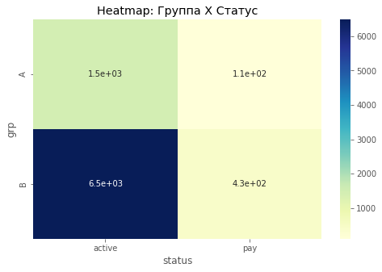

```python
# Создать бинарную колонку – status
# + Новый дата-сет active_users для таблицы сопряженности
active_users = full_data.query('activity == True')
active_users['status'] = active_users.rev > 0
active_users['status'] = active_users['status'].map({True:'pay', False:'active'})

# Таблица сопряженности: встречаемость
crosstab_table = pd.crosstab(active_users.grp, active_users.status)

# Таблица сопряженности: проценты по всему
crosstab_table_percentage = round(pd.crosstab(active_users.grp,
                                              active_users.status,
                                              normalize='all'),2)

# Хи-тест
c, p, dof, expected = stats.chi2_contingency(crosstab_table)
print('Chi_test_results: \n', 'chi_value:', c, '  df:', dof,
      '  p-value:', p, '\n \n',
      'H0: Взаимосвязи между Статусом и Группой нет \n',
      'H1: Взаимосвязь между Статусом и Группой присутствует \n')

if p < 0.05:
    print('p_value:',round(p,3),
          'принимаем альтернативную гипотезу H1: взаимосвязь между Статусом X Группа присутствует')
else:
    print('p_value:', round(p,3),
          'отклоняем альтернативную гипотезу H1: взаимосвязи между Статусом X Группа нет')


# Общий аутпут
display_side_by_side(crosstab_table, crosstab_table_percentage,
                     titles=['Встречаемость', '% всего'])

#Heatmap для таблиц сопряженности
plt.figure(figsize=(8,5))
graph_heatmap = sns.heatmap(crosstab_table, annot=True, cmap="YlGnBu").set(title='Heatmap: Группа X Статус')
graph_heatmap
```

**Интерпретация:** мы получили p-value > 0.05, что говорит о том, что взаимосвязи между Статусом X Группа, возможно, нет

Результаты пост-хоков будут такими же, поскольку мы тестим одну и ту же гипотезу (поэтому их проводить мы не будем)

#### Посчитаем мощность для конверсии

```python
effect_size = sqrt(c / active_users.shape[0])
effect_size
```

```
0.008262948959722865
```

[figure not shown]

### Интерпретация:

- Мощность теста низкая.
- Если мы хотим получить значимый результат при размере эффекта в 0.008, то нам нужно донабрать выборку
- Этот результат необходимо обсудить с заказчиком (м.б. размер эффекта его устраивает)

#### Перейдем к среднему чеку, ARPU и ARPPU

- Для всех метрик будем использовать бустрапирование по среднему

Вместо классик. тестов, мы используем бустрап, т.к. он не придирчив к отсуствию выполнения некоторых стат. допущений  
(например: у нас все метрики ненормально распределены)

Но, t-test может закрыть глаза на ненормальное распределение, если объем выборки небольшой. Но это выполняется только при условии, что распределения средних стремятся к нормальной форме. Вот это как раз таки мы можем частично увидеть в бустрепе!

**Гипотезы** для трех процедур похожи:

1. H0: revenue в выборке ARPU, ARPPU, общей (средний чек) различаются в двух группах
2. H1: revenue в выборке ARPU, ARPPU, общей (средний чек) не различаются в двух группах

PS: я использовал странную формулировку в гипотезах, потому что мы бустрапируем не ARPU, ARPPU, а revenue в условиях ARPU, ARPPU.

**Начнем со среднего чека!**

```
    Напишите статистику

    Варианты ответа:
        - mean (среднее)
        - median (медиана)

    Статистика:


    Вы написали неверное название статистики

    Верные названия:
        - mean (среднее)
        - median (медиана)

    Попробуйте снова: mean
```

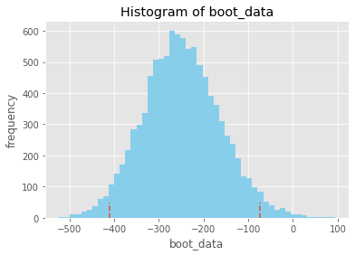

```python
bootstrap_mean_check = get_bootstrap(
                         full_data.query('grp == "A" & rev > 0').rev,
                         full_data.query('grp == "B" & rev > 0 ').rev,
                         boot_it=10000)
```

```python
# Достаем p-value и значения CI для среднего чека
print('p-value:', bootstrap_mean_check["p_value"], '\n')
print('CI_values:', bootstrap_mean_check['ci'], '\n')

if bootstrap_mean_check["p_value"] < 0.05:
    print('p_value:', round(bootstrap_mean_check["p_value"], 3),
          '| принимаем H1: разница между группами присутствует')
else:
    print('p_value:', round(bootstrap_mean_check["p_value"], 3),
          '| отклоняем H1: разница между группами отсутствует')
```

```
p-value: 0.0038376774500565305

CI_values:                 0
0.025 -410.880472
0.975  -73.088177

p_value: 0.004 | принимаем H1: разница между группами присутствует
```

#### Интерпретация:

1. Результат стат. значимый, p-value < 0.05
2. 0 не входит в доверительный интервал

#### Вывод:

Средний чек в обеих группах, возможно, различается

#### Оценим мощность и размер эффекта для среднего чека

- Здесь мы будем использовать t-test, поскольку по графику бустрапа видно, что разница средних стремится к нормальной форме

#### Перед началом т-теста проверим равенство дисперсий в двух группах

- чтобы узнать, какой параметр поставить при проведении t-test

```python
stats.levene(full_data.query('grp == "A" & rev > 0').rev,
             full_data.query('grp == "B" & rev > 0 ').rev)
```

```
LeveneResult(statistic=4.478900854248498, pvalue=0.03477352573759214)
```

#### Интерпретация:

- p-value значимый (< 0.05)
- Принимаем H1: дисперсии в двух группах не равны

#### Проводим т-тест для среднего чекаа

```python
stats.ttest_ind(full_data.query('grp == "A" & rev > 0').rev,
                full_data.query('grp == "B" & rev > 0 ').rev,
                equal_var=False)
# equal_var = аргумент для групп с неравными дисперсиями
```

```
Ttest_indResult(statistic=-2.8670185482728643, pvalue=0.004731862454849822)
```

#### Интерпретация:

- p-value значимый (< 0.05)
- Принимаем H1: средние в двух группах различаются

#### Считаем размер эффекта для среднего чека

```python
# Размер эффекта
print("Cohen's d: ", cohen_d(full_data.query('grp == "A" & rev > 0').rev,
      full_data.query('grp == "B" & rev > 0').rev), '\n')

# Размер группы А
print('Размер группы А: ',
      len(full_data.query('grp == "A" & rev > 0').rev), '\n')

# Размер группы B
print('Размер группы B: ', len(full_data.query('grp == "B" & rev > 0').rev))
```

```
Cohen's d:  -0.3182002443724011

Размер группы А:  107

Размер группы B:  434
```

#### Считаем мощность, с помощью g-power

[figure not shown]

#### Интерпретация:

1. Размер эффекта маленький
2. Но мощность при собранной выборке достигает конвенциональных значений ~ 0.84
3. Отрицательный размер эффекта со значением 0.32 означает, что среднее значение группы B на 0.32 стандартных отклонений больше, чем среднее значение группы A

#### Перейдем к бустрапу ARPU

```
    Напишите статистику

    Варианты ответа:
        - mean (среднее)
        - median (медиана)

    Статистика: mean
```

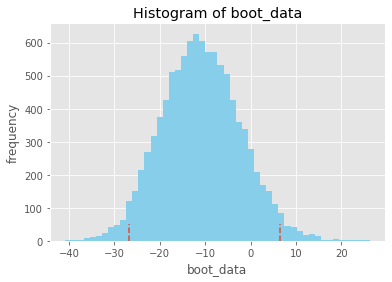

```python
bootstrap_arpu = get_bootstrap(
            full_data.query('activity == True & grp == "A"').rev,
            full_data.query('activity == True & grp == "B"').rev,
            boot_it=10000)
```

```python
# Достаем p-value и значения CI для ARPU
print('p-value:', bootstrap_arpu["p_value"], '\n')
print('CI_values:', bootstrap_arpu['ci'], '\n')

if bootstrap_arpu["p_value"] < 0.05:
    print('p_value:', round(bootstrap_arpu["p_value"], 3),
          'принимаем H1: разница между группами присутствует')
else:
    print('p_value:', round(bootstrap_arpu["p_value"], 3),
          'отклоняем H1: разница между группами отсутствует')
```

```
p-value: 0.2081069828882196

CI_values:                0
0.025 -26.898178
0.975   6.512771

p_value: 0.208 отклоняем H1: разница между группами отсутствует
```

#### Интерпретация:

1. p-value незначимый (> 0.05)
2. Ноль входит в доверительный интервал
3. Мы принимаем H0: разница между группами отсутствует

#### Вывод:

При сравнение средних по revenue в выборке ARPU, разница между группами A и B, возможно, не присутствует

#### Давайте сравним результаты бустрапа с t-test по ARPU

#### Но перед этим – проверим равенство дисперсий в двух группах

- чтобы узнать, какой параметр поставить при проведении t-test

```python
stats.levene(full_data.query('activity == True & grp == "A"').rev,
             full_data.query('activity == True & grp == "B"').rev)
```

```
LeveneResult(statistic=1.4169289256466395, pvalue=0.23394283915362288)
```

#### Интерпретация:

- p-value не значимый
- Принимаем H0: дисперсии в двух группах равны

#### Проводим т-тест для ARPU

```python
stats.ttest_ind(full_data.query('activity == True & grp == "A"').rev,
                full_data.query('activity == True & grp == "B"').rev)
```

```
Ttest_indResult(statistic=-1.1903482371334195, pvalue=0.2339428391527247)
```

#### Интерпретация:

- p-value практически такой же, что и в бустрапе
- Принимаем H0: средние в двух группах не различаются

#### Вывод:

Средние по Revenue в выборках ARPU в двух группах скорее всего не различаются

#### Посчитаем размер эффекта для ARPU

```python
# Размер эффекта
print("Cohen's d: ",
      cohen_d(full_data.query('activity == True & grp == "A"').rev,
              full_data.query('activity == True & grp == "B"').rev), '\n')

# Размер группы А
print('Размер группы А: ',
      len(full_data.query('activity == True & grp == "A"')), '\n')

# Размер группы B
print('Размер группы B: ',
      len(full_data.query('activity == True & grp == "B"')))
```

```
Cohen's d:  -0.03405534098734651

Размер группы А:  1567

Размер группы B:  6923
```

#### Считаем мощность, с помощью g-power

[figure not shown]

#### Интерпретация:

- Мощность теста низкая.
- Если мы хотим получить значимый результат при размере эффекта в -0.03, то нам нужно донабрать выборку
- Этот результат необходимо обсудить с заказчиком (м.б. размер эффекта его устраивает)

#### Теперь перейдем к ARPPU

```
    Напишите статистику

    Варианты ответа:
        - mean (среднее)
        - median (медиана)

    Статистика: mean
```

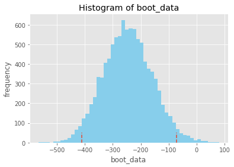

```python
bootstrap_arppu = get_bootstrap(
            full_data.query('activity == True & grp == "A" & rev > 0').rev,
            full_data.query('activity == True & grp == "B" & rev > 0').rev,
            boot_it=10000)
```

```python
# Достаем p-value и значения CI для ARPPU
print('p-value:', bootstrap_arppu["p_value"], '\n')
print('CI_values:', bootstrap_arppu['ci'], '\n')

if bootstrap_arppu["p_value"] < 0.05:
    print('p_value:', round(bootstrap_arppu["p_value"], 3),
          'принимаем H1: разница между группами присутствует')
else:
    print('p_value:', round(bootstrap_arppu["p_value"], 3),
          'отклоняем H1: разница между группами отсутствует')
```

```
p-value: 0.004564231262166636

CI_values:                 0
0.025 -411.067084
0.975  -72.675792

p_value: 0.005 принимаем H1: разница между группами присутствует
```

#### Интерпретация:

1. Результат стат. значимый (p-value < 0.05)
2. 0 не входит в доверительный интервал

#### Вывод:

При сравнение средних по revenue в выборке ARPPU, разница между группами A и B, возможно, присутствует

#### Оценим мощность и размер эффекта для ARPPU

- Здесь мы будем использовать t-test, поскольку по графика бустрапа видно, что разница средних стремится к нормальной форме

#### Перед началом т-теста проверим равенство дисперсий в двух группах

- чтобы узнать, какой параметр поставить при проведении t-test

```python
stats.levene(full_data.query('activity == True & grp == "A" & rev > 0').rev,
             full_data.query('activity == True & grp == "B" & rev > 0').rev)
```

```
LeveneResult(statistic=4.478900854248498, pvalue=0.03477352573759214)
```

#### Интерпретация:

- p-value значимый (<0.05)
- Принимаем H1: дисперсии в двух группах не равны

#### Проводим т-тест для ARPPU

```python
stats.ttest_ind(full_data.query('activity == True & grp == "A" & rev > 0').rev,
                full_data.query('activity == True & grp == "B" & rev > 0').rev,
                equal_var=False)
```

```
Ttest_indResult(statistic=-2.8670185482728643, pvalue=0.004731862454849822)
```

#### Интерпретация:

- p-value значимый (<0.05)
- Принимаем H1: средние в двух группах различаются

#### Считаем размер эффекта для ARPPU

```python
# Размер эффекта
print("Cohen's d: ",
      cohen_d(full_data.query('activity == True & grp == "A" & rev > 0').rev,
              full_data.query('activity == True & grp == "B" & rev > 0').rev),
      '\n')

# Размер группы А
print('Размер группы А: ',
      len(full_data.query('activity == True & grp == "A" & rev > 0')), '\n')

# Размер группы B
print('Размер группы B: ',
      len(full_data.query('activity == True & grp == "B" & rev > 0')))
```

```
Cohen's d:  -0.3182002443724011

Размер группы А:  107

Размер группы B:  434
```

#### Интерпретация:

1. Размер эффекта и объем выборок такие же, что и для среднего чека. Поэтому, значение мощности будет таким же
2. Следовательно, интерпретация схожая: отрицательный размер эффекта со значением 0.32 означает, что среднее значение группы B выборки ARPPU на 0.32 стандартных отклонений больше, чем среднее значение группы A выборки ARPPU

### Основные выводы по заданию №1:

**Конверсия**

- результат Хи-теста не значимый
- размер эффекта = 0.008 (мало) и мощность низкая
- Это означает, что при большем объеме выборки мы сможем достичь стат. значимую, но очень слабую корреляцию

**Вывод:** эти показатели надо обсуждать с заказчиком и знать контекст данных. Но, думаю, что новая технология не сильно "повлияла" на конверсию

**Средний чек**

- результат бустрапа и т-теста значимые
- размер эффекта низкий = -0.32, но мощность достигает конвенциональных значений
- Это означает, что среднее значение тестовой группы на 0.32 стандартных отклонений больше, чем среднее значение контрольной группы

**Вывод:** опять-таки надо разговаривать с заказчиком. Но, думаю, что здесь новая технология не сильно "повлияла" на средний чек, поскольку по процентам это означает, что ~ 51-52% средних чеков из контрольной группы будут ниже среднего (средних чеков) тестовой группы. То есть соотношение примерно равное (ссылка: https://www.statology.org/interpret-cohens-d/)

**ARPU**

- результат бустрапа и т-теста незначимые
- размер эффекта = -0.03 (мало) и мощность низкая
- Это означает, что при большем объеме выборки мы увидим, что среднее значение тестовой группы на 0.03 стандартных отклонений больше, чем среднее значение контрольной группы

**Вывод:** надо обсуждать с заказчиком. Думаю, что новая технология не сильно "повлияла" на ARPU, поскольку по процентам это означает, что ~ 50% средних чеков выборки ARPU из контрольной группы будут ниже среднего (средних чеков) выборки ARPU тестовой группы. Здесь соотношение практически эквивалетное.

**ARPPU**

- результат бустрапа и т-теста значимые
- размер эффекта и мощность такие же, что и для среднего чека.

Следовательно, интерпретация для ARPPU будет такой же, что и для среднего чека

### Решения:

- Изменить новую технологию, поскольку она слабо "повлияла" на метрики
- Запустить новый а/б тест с другой технологией

### Что нужно обсудить?

- 149 багованные респонденты (кто не вошел в приложение, но купил продукт)
- метрики (что считать выбросом, а что нет)
- альфа-значение
- значение мощности
- значения размеров эффекта

### Задание №2. SQL

**2.1. Очень усердные ученики:**

- Образовательные курсы состоят из различных уроков, каждый из которых состоит из нескольких маленьких заданий.
- Каждое такое маленькое задание называется "горошиной".
- Назовём очень усердным учеником того пользователя, который хотя бы раз за текущий месяц правильно решил 20 горошин за час.
- Дана таблица peas
- Необходимо написать оптимальный запрос, который даст информацию о количестве очень усердных студентов за март 2020 года.
- NB! Под усердным студентом мы понимаем студента, который правильно решил 20 задач за текущий месяц.

Я не совсем понял условие задания, поэтому я написал два запроса:

1. Первый запрос в Postgresql, который выдает кол-во студентов, кто верно решил 20 горошин за час в марте 2020 года
2. Второй запрос в Clickhouse, который выдает кол-во студентов, кто решил 20 горошин в марте 2020 года

```python
# Postgresql(Redash)
# Кол-во студентов, кто верно решил 20 горошин за час в марте 2020 года
"""
SELECT
COUNT(DISTINCT(per_hour.st_id)) as otvet
FROM
    (SELECT
        st_id,
        SUM(correct) OVER (PARTITION BY st_id ORDER BY timest ASC RANGE BETWEEN CURRENT ROW AND '1 hour' FOLLOWING
         ) AS goroshina_hour
FROM peas
WHERE timest >= '2020-03-01 00:00:00' AND correct = '1') AS per_hour
WHERE per_hour.goroshina_hour >= 20"""
```

```
"\nSELECT\nCOUNT(DISTINCT(per_hour.st_id)) as otvet\nFROM\n    (SELECT \n        st_id, \n        SUM(correct) OVER (PARTITION BY st_id ORDER BY timest ASC RANGE BETWEEN CURRENT ROW AND '1 hour' FOLLOWING\n         ) AS goroshina_hour               \nFROM peas\nWHERE timest >= '2020-03-01 00:00:00' …
```

```python
# Clickhouse(Redash)
# Кол-во студентов, кто решил 20 горошин в марте 2020 года
'''
SELECT
    COUNT(DISTINCT(st_id)) as otvet
FROM(
    SELECT
        st_id,
        SUM(correct) as correct_peas
    FROM peas
    WHERE toStartOfMonth(timest) = '2020-03-01'
    GROUP BY st_id
    HAVING correct_peas >= 20)
'''
```

```
"\nSELECT\n    COUNT(DISTINCT(st_id)) as otvet\nFROM(\n    SELECT \n        st_id, \n        SUM(correct) as correct_peas\n    FROM peas\n    WHERE toStartOfMonth(timest) = '2020-03-01'\n    GROUP BY st_id\n    HAVING correct_peas >= 20)\n"
```

**2.2. Оптимизация воронки:**

- Образовательная платформа предлагает пройти студентам курсы по модели trial: студент может решить бесплатно лишь 30 горошин в день.
- Для неограниченного количества заданий в определенной дисциплине студенту необходимо приобрести полный доступ.
- Команда провела эксперимент, где был протестирован новый экран оплаты.
- Даны таблицы: peas, studs и checks
- Необходимо в одном запросе выгрузить следующую информацию о группах пользователей:
  - ARPU, ARPAU, CR в покупку, СR активного пользователя в покупку
  - CR пользователя из активности по математике (subject = ’math’) в покупку курса по математике.

```python
# Запрос выполнен в ClickHouse (Redash)
# Активные пользователи – таблица peas, правильно ответили хотя бы на одну горошину
# Платящие пользователи – таблица final_project_check
# Все пользователи – таблица whole_students
# Full_table: таблица со всеми типами пользователями

'''
WITH active_students AS(
SELECT
    st_id,
    subject as subject,
    SUM(correct) as correct
    FROM peas
    GROUP BY subject, st_id
    HAVING correct >= 1),

purshase_students as (
SELECT
    st_id,
    subject,
    SUM(money) as rev_subject
    FROM final_project_check
    GROUP BY st_id, subject
),

whole_students as(
SELECT
DISTINCT(st_id) as st_id,
test_grp
FROM studs
),

full_table as (
SELECT
    act.st_id as a_id, --id активных пользователей
    act.subject as a_subject,--предметы активных пользователей
    act.correct as correct, --правильные ответы активных пользователей
    partial.st_id as w_id, --id всех пользователей
    partial.grp as grp, --группа пользователей
    partial.p_id as p_id,--id платящих пользователей
    partial.subject as p_subject, --предметы платящих пользователей
    partial.rev as rev --чеки платящих пользователей
FROM active_students as act
RIGHT JOIN
(SELECT w.st_id as st_id,
       w.test_grp as grp,
       p.st_id as p_id,
       p.subject as subject,
       p.rev_subject as rev
    FROM whole_students as w
LEFT JOIN
    (SELECT *
    FROM purshase_students) as p
USING st_id) as partial
USING st_id, subject)

SELECT
    grp,
    SUM(rev) / COUNT(DISTINCT(w_id)) AS ARPU,
    SUM(rev) / COUNT(DISTINCT(a_id)) AS ARPAU,
    COUNT(DISTINCT (p_id)) / COUNT(DISTINCT (w_id)) * 100 AS CR_pokupla,
    COUNT(DISTINCT (p_id)) / COUNT(DISTINCT (a_id)) * 100 AS CR_active_pokupka,
    SUM(CASE WHEN p_subject = 'Math' THEN 1 ELSE 0 END) / SUM(CASE WHEN a_subject = 'Math' THEN 1 ELSE 0 END)*100 AS CR_active_math
FROM full_table
GROUP BY grp
'''
```

```
"\nWITH active_students AS(\nSELECT \n    st_id,\n    subject as subject,\n    SUM(correct) as correct\n    FROM peas\n    GROUP BY subject, st_id\n    HAVING correct >= 1),\n    \npurshase_students as (\nSELECT\n    st_id,\n    subject,\n    SUM(money) as rev_subject\n    FROM final_project_check\n…
```

### Задание №3. Функция метрик

**Условия:**

1. Реализуйте функцию, которая будет автоматически подгружать информацию из дополнительного файла groups_add.csv (заголовки могут отличаться) и на основании дополнительных параметров пересчитывать метрики.
1. Реализуйте функцию, которая будет строить графики по получаемым метрикам.

```python
def metrics(path:str, id_column:str, group_column:str):
    '''
    Функция подгружает дополнительный дата-сет, пересчитывает и строит графики по основным метрикам

    :path – путь к дополнительному дата-сету (str)

    :id_column – название колонки id в дополнительном дата-сете (str)

    :products – название колонки grp в дополнительном дата-сете (str)
    '''

    # Загрузка основных дата-сетов
    groups = pd.read_csv('groups.csv', sep=';')
    active_studs = pd.read_csv('active_studs.csv')
    checks = pd.read_csv('checks.csv', sep=';')

    # Исключение №1 о формате таблиц
    if '.csv' in path:
        group_add = pd.read_csv(path)
    else:
        print('Ошибка 1: напишите нужный формат таблицы: .csv')

    # Меняем названия колонок (если прислали отличные от исходных)
    group_add.rename(columns = {id_column:'id', group_column:'grp'},
                                inplace = True)

    # ––––Склеивание––––––
    # Склеивание основного дата-сета и дополнительного
    connected_data = pd.concat([groups, group_add],
                               ignore_index=True, sort=False)

    # Добавление булевой колонки
    connected_data['activity'] = np.isin(connected_data['id'],
                                         active_studs['student_id']).tolist()

    # Переименование колонки, чтобы merge сработало
    checks = checks.rename(columns={'student_id': 'id'})

    # Склеивание с помощью left-merge
    full_data = connected_data.merge(checks, on='id', how='left')

    # Заполним NA в колонке с чеками
    full_data['rev'] = full_data.rev.fillna(0)

    # Изменение статус багованных пользователей
    full_data['activity'] = np.where(full_data['rev'] > 0, True,
                                     full_data.activity)

    # ––––Подсчет конверсии––––––
    cr_data = full_data.query('activity == True') \
                       .groupby('grp', as_index=False) \
                       .agg({'activity':'count'})

    cr_data['payment'] = full_data.query('rev > 0') \
                                  .groupby('grp').agg({'activity':'count'}) \
                                  .activity.to_list()

    cr_data['cr_coeff'] = round((cr_data.payment / cr_data.activity) * 100, 2)

    # ––––Подсчет среднего и медианного чека––––
    check_data = full_data.query('rev > 0').groupby('grp', as_index=False) \
            .agg({'rev':'mean'}).round(2).rename(columns={'rev':'avg_check'})

    check_data['median_check'] = full_data.query('rev > 0') \
            .groupby('grp', as_index=False) \
            .agg({'rev':'median'}).round(2).rev.to_list()

    # ––––Подсчет ARPU и ARPPU––––
    arpu_data = full_data.query('activity == True') \
            .groupby('grp', as_index = False).agg({'id':'count', 'rev':'sum'}) \
            .rename(columns={'id':'num_users'}).round()

    arpu_data['arpu'] = round(arpu_data['rev'] / arpu_data['num_users'], 1)

    arppu_data = full_data.query('activity == True & rev > 0') \
            .groupby('grp', as_index=False).agg({'id':'count', 'rev':'sum'}) \
            .rename(columns={'id':'num_users'}).round()

    arppu_data['arppu'] = round(arppu_data['rev'] / arppu_data['num_users'], 1)

    # ––––Графики––––

    # Создаем две группы
    pay_user_A = full_data.query('rev > 0 & grp == "A"')
    pay_user_B = full_data.query('rev > 0 & grp == "B"')

    # Создаем 3 рамки для графиков
    fig, axes = plt.subplots(4, 2, figsize=(15, 5))

    # Общее название
    fig.suptitle('РАСПРЕДЕЛЕНИЕ МЕТРИК')

    # Названия для отдельных графиков
    axes[0,0].set_title('Кол-во активных и платящих пользователей')
    axes[0,1].set_title('Конверсия по группам')

    axes[1,0].set_title('Распределение чеков группы A')
    axes[1,1].set_title('Распределение чеков группы B')

    axes[2,0].set_title('Кол-во пользователей и доход (ARPU)')
    axes[2,1].set_title('ARPU между группами')

    axes[3,0].set_title('Кол-во пользователей и доход (ARPPU)')
    axes[3,1].set_title('ARPPU между группами')

    # Размер графиков
    fig.set_size_inches(20, 30)

    # Первый график
    # Перевод с широкого формата на длинный
    cr_data_long = cr_data.rename(columns={'activity':'activity_status',
                                           'payment':'payment_status'})

    cr_data_long = pd.melt(cr_data_long, id_vars='grp',
                           value_vars=['activity_status', 'payment_status'])

    # Рисуем график №1
    graph1 = sns.barplot(x="variable", y="value", hue="grp",
                         data=cr_data_long, ax=axes[0,0])

    # Подписи для первого графика (цифры над столбцами)
    for container in graph1.containers:
        graph1.bar_label(container)

    # Рисуем график №2
    graph2 = sns.barplot(x="grp", y="cr_coeff",
                         data=cr_data, ax=axes[0,1])

    # Подписи для второго графика (цифры над столбцами)
    for container in graph2.containers:
        graph2.bar_label(container)

    # Третий график
    graph3 = sns.distplot(pay_user_A.rev, color="g",ax=axes[1,0])
    graph3.axvline(x = pay_user_A.rev.mean(), color='red')
    graph3.axvline(x = pay_user_A.rev.median(), color='blue')

    # Четвертый график
    graph4 = sns.distplot(pay_user_B.rev, ax=axes[1,1])
    graph4.axvline(x = pay_user_B.rev.mean(), color='red')
    graph4.axvline(x = pay_user_B.rev.median(), color='blue')

    # Легенды
    bbox_props = dict(boxstyle="round", fc="w", ec="0.5")

    # Легенда среднего для третьего графика
    axes[1,0].annotate(f"Mean = {round(pay_user_A.rev.mean(),2)}",
                       xy=(0.98, 0.95), xycoords='axes fraction',
                       fontsize=16, horizontalalignment='right',
                       bbox=bbox_props, color='red')

    # Легенда медианы для третьего графика
    axes[1,0].annotate(f"Median = {round(pay_user_A.rev.median(),2)}",
                       xy=(0.98, 0.88), xycoords='axes fraction',
                       fontsize=16, horizontalalignment='right',
                       bbox=bbox_props, color='blue')

    # Легенда среднего для четвертого графика
    axes[1,1].annotate(f"Mean = {round(pay_user_B.rev.mean(),2)}",
                       xy=(0.98, 0.95), xycoords='axes fraction',
                       fontsize=16, horizontalalignment='right',
                       bbox=bbox_props, color='red')

    # Легенда медианы для четвертого графика
    axes[1,1].annotate(f"Median = {round(pay_user_B.rev.median(),2)}",
                       xy=(0.98, 0.88), xycoords='axes fraction',
                       fontsize=16, horizontalalignment='right',
                       bbox=bbox_props, color='blue')

    # Пятый график
    # Перевод с широкого формата на длинный
    arpu_data_long = pd.melt(arpu_data, id_vars='grp',
                             value_vars=['num_users', 'rev'])

    # Рисуем график №5
    graph5 = sns.barplot(x="variable", y="value", hue="grp",
                         data=arpu_data_long, ax=axes[2,0])

    # Подписи для пятого графика (цифры над столбцами)
    for container in graph5.containers:
        graph5.bar_label(container)

    # Рисуем график №6
    graph6 = sns.barplot(x="grp", y="arpu",
                         data=arpu_data, ax=axes[2,1])

    # Подписи для шестого графика (цифры над столбцами)
    for container in graph6.containers:
        graph6.bar_label(container)

    # Седьмой график
    # Перевод с широкого формата на длинный
    arppu_data_long = pd.melt(arppu_data, id_vars='grp',
                              value_vars=['num_users', 'rev'])

    # Рисуем график №7
    graph7 = sns.barplot(x="variable", y="value",
                         hue="grp", data=arppu_data_long,
                         ax=axes[3,0])

    # Подписи для седьмого графика (цифры над столбцами)
    for container in graph7.containers:
        graph7.bar_label(container)

    # Рисуем график №8
    graph7 = sns.barplot(x="grp", y="arppu",
                         data=arppu_data, ax=axes[3,1])

    # Подписи для восьмого графика (цифры над столбцами)
    for container in graph7.containers:
        graph7.bar_label(container)

    # Вывод данных
    return display_side_by_side(cr_data, check_data,
                                arpu_data, arppu_data,
                     titles = ['Конверсия', 'Mean & Median чек',
                               'ARPU', 'ARPPU']),axes[0], axes[1]
```

Конверсия

|  | grp | activity | payment | cr_coeff |
| --- | --- | --- | --- | --- |
| 0 | A | 1567 | 107 | 6.83 |
| 1 | B | 6923 | 434 | 6.27 |

Mean & Median чек

|  | grp | avg_check | median_check |
| --- | --- | --- | --- |
| 0 | A | 860.71 | 690.0 |
| 1 | B | 1108.82 | 935.0 |

ARPU

|  | grp | num_users | rev | arpu |
| --- | --- | --- | --- | --- |
| 0 | A | 1567 | 92096.0 | 58.8 |
| 1 | B | 6923 | 481230.0 | 69.5 |

ARPPU

|  | grp | num_users | rev | arppu |
| --- | --- | --- | --- | --- |
| 0 | A | 107 | 92096.0 | 860.7 |
| 1 | B | 434 | 481230.0 | 1108.8 |

```
(None,
 array([<AxesSubplot:title={'center':'Кол-во активных и платящих пользователей'}, xlabel='variable', ylabel='value'>,
        <AxesSubplot:title={'center':'Конверсия по группам'}, xlabel='grp', ylabel='cr_coeff'>],
       dtype=object),
 array([<AxesSubplot:title={'center':'Распределение чеков группы A'}, xlabel='rev', ylabel='Density'>,
        <AxesSubplot:title={'center':'Распределение чеков группы B'}, xlabel='rev', ylabel='Density'>],
       dtype=object))
```

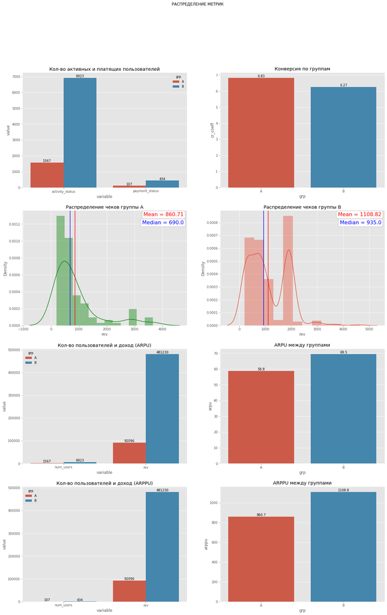

```python
#Пример работы
metrics('group_add.csv', 'id', 'grp')
```